# Global Oilseed Supply from 2012-2022

This data was pulled from the United States Department of Agriculture Foreign Agriculture Service (USDA FSA) Production, Supply and Distribution (PSD) online database using the custom query to create an Excel document that was then converted to a CSV file. This data can be found at the USAID FSA PSD at https://apps.fas.usda.gov/psdonline/app/index.html#/app/home.

```python
import pandas as pd
import numpy as np
import matplotlib as plt
import seaborn as sns

%matplotlib inline
```

```python
df = pd.read_csv("global_oilseed_2012-2022.csv")
df
```

|  | Attribute | Year | Country | Oilseed, Peanut | Oilseed, Rapeseed | Oilseed, Soybean | Oilseed, Soybean (Local) | Oilseed, Sunflowerseed | Unit Description |
| --- | --- | --- | --- | --- | --- | --- | --- | --- | --- |
| 0 | Beginning Stocks | 2012/2013 | Argentina | 269 | 0 | 14338 | 2679 | 369 | (1000 MT) |
| 1 | Beginning Stocks | 2012/2013 | Australia | 0 | 572 | 3 | 0 | 0 | (1000 MT) |
| 2 | Beginning Stocks | 2012/2013 | Bangladesh | 0 | 152 | 30 | 0 | 0 | (1000 MT) |
| 3 | Beginning Stocks | 2012/2013 | Barbados | 0 | 0 | 5 | 0 | 0 | (1000 MT) |
| 4 | Beginning Stocks | 2012/2013 | Belarus | 0 | 0 | 0 | 0 | 0 | (1000 MT) |
| ... | ... | ... | ... | ... | ... | ... | ... | ... | ... |
| 5551 | Ending Stocks | 2022/2023 | Uzbekistan | 0 | 0 | 3 | 0 | 19 | (1000 MT) |
| 5552 | Ending Stocks | 2022/2023 | Venezuela | 0 | 0 | 2 | 0 | 0 | (1000 MT) |
| 5553 | Ending Stocks | 2022/2023 | Vietnam | 39 | 0 | 392 | 0 | 0 | (1000 MT) |
| 5554 | Ending Stocks | 2022/2023 | Zambia | 8 | 0 | 32 | 0 | 0 | (1000 MT) |
| 5555 | Ending Stocks | 2022/2023 | Zimbabwe | 4 | 0 | 7 | 0 | 0 | (1000 MT) |

5556 rows × 9 columns

Since every oilseed crop is in 1000 metric tons (MT) then this column can be dropped

```python
df = df.drop(columns="Unit Description")
df.head()
```

|  | Attribute | Year | Country | Oilseed, Peanut | Oilseed, Rapeseed | Oilseed, Soybean | Oilseed, Soybean (Local) | Oilseed, Sunflowerseed |
| --- | --- | --- | --- | --- | --- | --- | --- | --- |
| 0 | Beginning Stocks | 2012/2013 | Argentina | 269 | 0 | 14338 | 2679 | 369 |
| 1 | Beginning Stocks | 2012/2013 | Australia | 0 | 572 | 3 | 0 | 0 |
| 2 | Beginning Stocks | 2012/2013 | Bangladesh | 0 | 152 | 30 | 0 | 0 |
| 3 | Beginning Stocks | 2012/2013 | Barbados | 0 | 0 | 5 | 0 | 0 |
| 4 | Beginning Stocks | 2012/2013 | Belarus | 0 | 0 | 0 | 0 | 0 |

```python
unique_values = df.nunique(0)
unique_values
```

```
Attribute                      6
Year                          11
Country                       85
Oilseed, Peanut              667
Oilseed, Rapeseed            621
Oilseed, Soybean            1169
Oilseed, Soybean (Local)     111
Oilseed, Sunflowerseed       514
dtype: int64
```

```python
df.info()
```

```
<class 'pandas.core.frame.DataFrame'>
RangeIndex: 5556 entries, 0 to 5555
Data columns (total 8 columns):
 #   Column                    Non-Null Count  Dtype
---  ------                    --------------  -----
 0   Attribute                 5556 non-null   object
 1   Year                      5556 non-null   object
 2   Country                   5556 non-null   object
 3   Oilseed, Peanut           5556 non-null   int64
 4   Oilseed, Rapeseed         5556 non-null   int64
 5   Oilseed, Soybean          5556 non-null   int64
 6   Oilseed, Soybean (Local)  5556 non-null   int64
 7   Oilseed, Sunflowerseed    5556 non-null   int64
dtypes: int64(5), object(3)
memory usage: 347.4+ KB
```

Next we need to clean up the Year column so that it is more readable for analysis, instead of being a string value we'll convert it to a date/time data type. To do this we'll remove the "/" and just use the year that the growing season starts as our year. As stated in USDA PSD FAQ's the years are marketing years, except for in the Southern Hemisphere where the second year is the marketing year. Instead of dividing everything by Northern and Southern we're just going to use the first years for everything, our analysis doesn't need to be so precise to follow the growing seasons so closely.

```python
df[["Year", "Year2"]] = df["Year"].str.split("/", expand=True)
df.head()
```

|  | Attribute | Year | Country | Oilseed, Peanut | Oilseed, Rapeseed | Oilseed, Soybean | Oilseed, Soybean (Local) | Oilseed, Sunflowerseed | Year2 |
| --- | --- | --- | --- | --- | --- | --- | --- | --- | --- |
| 0 | Beginning Stocks | 2012 | Argentina | 269 | 0 | 14338 | 2679 | 369 | 2013 |
| 1 | Beginning Stocks | 2012 | Australia | 0 | 572 | 3 | 0 | 0 | 2013 |
| 2 | Beginning Stocks | 2012 | Bangladesh | 0 | 152 | 30 | 0 | 0 | 2013 |
| 3 | Beginning Stocks | 2012 | Barbados | 0 | 0 | 5 | 0 | 0 | 2013 |
| 4 | Beginning Stocks | 2012 | Belarus | 0 | 0 | 0 | 0 | 0 | 2013 |

```python
df = df.drop(columns="Year2")
df.head()
```

|  | Attribute | Year | Country | Oilseed, Peanut | Oilseed, Rapeseed | Oilseed, Soybean | Oilseed, Soybean (Local) | Oilseed, Sunflowerseed |
| --- | --- | --- | --- | --- | --- | --- | --- | --- |
| 0 | Beginning Stocks | 2012 | Argentina | 269 | 0 | 14338 | 2679 | 369 |
| 1 | Beginning Stocks | 2012 | Australia | 0 | 572 | 3 | 0 | 0 |
| 2 | Beginning Stocks | 2012 | Bangladesh | 0 | 152 | 30 | 0 | 0 |
| 3 | Beginning Stocks | 2012 | Barbados | 0 | 0 | 5 | 0 | 0 |
| 4 | Beginning Stocks | 2012 | Belarus | 0 | 0 | 0 | 0 | 0 |

```python
df["Year"] = pd.to_datetime(df["Year"])
df.info()
```

```
<class 'pandas.core.frame.DataFrame'>
RangeIndex: 5556 entries, 0 to 5555
Data columns (total 8 columns):
 #   Column                    Non-Null Count  Dtype
---  ------                    --------------  -----
 0   Attribute                 5556 non-null   object
 1   Year                      5556 non-null   datetime64[ns]
 2   Country                   5556 non-null   object
 3   Oilseed, Peanut           5556 non-null   int64
 4   Oilseed, Rapeseed         5556 non-null   int64
 5   Oilseed, Soybean          5556 non-null   int64
 6   Oilseed, Soybean (Local)  5556 non-null   int64
 7   Oilseed, Sunflowerseed    5556 non-null   int64
dtypes: datetime64[ns](1), int64(5), object(2)
memory usage: 347.4+ KB
```

We can also make the data easier to manipulate by renaming the top columns. We know that they are all oilseeds, so we can remove that part. It is also easier to just put "Soybean(Local)" as "Local Soybeans" it does remove some special characters and makes it easier for our autocomplete to catch without us having to type out "Soybean" all the way.

```python
df = df.rename(columns={"Oilseed, Peanut":"Peanut", "Oilseed, Rapeseed":"Rapeseed", "Oilseed, Soybean":"Soybean",
    "Oilseed, Soybean (Local)": "Local Soybean", "Oilseed, Sunflowerseed":"Sunflowerseed"})

df.head()
```

|  | Attribute | Year | Country | Peanut | Rapeseed | Soybean | Local Soybean | Sunflowerseed |
| --- | --- | --- | --- | --- | --- | --- | --- | --- |
| 0 | Beginning Stocks | 2012-01-01 | Argentina | 269 | 0 | 14338 | 2679 | 369 |
| 1 | Beginning Stocks | 2012-01-01 | Australia | 0 | 572 | 3 | 0 | 0 |
| 2 | Beginning Stocks | 2012-01-01 | Bangladesh | 0 | 152 | 30 | 0 | 0 |
| 3 | Beginning Stocks | 2012-01-01 | Barbados | 0 | 0 | 5 | 0 | 0 |
| 4 | Beginning Stocks | 2012-01-01 | Belarus | 0 | 0 | 0 | 0 | 0 |

```python
country_df = df.groupby(by=["Country", "Attribute"])
country_df.first()
```

| Country | Attribute | Year | Peanut | Rapeseed | Soybean | Local Soybean | Sunflowerseed |
| --- | --- | --- | --- | --- | --- | --- | --- |
| Algeria | Beginning Stocks | 2015-01-01 | 0 | 0 | 0 | 0 | 0 |
|  | Domestic Consumption | 2015-01-01 | 0 | 0 | 0 | 0 | 0 |
|  | Ending Stocks | 2015-01-01 | 0 | 0 | 0 | 0 | 0 |
|  | Exports | 2015-01-01 | 0 | 0 | 0 | 0 | 0 |
|  | Imports | 2015-01-01 | 0 | 0 | 0 | 0 | 0 |
| ... | ... | ... | ... | ... | ... | ... | ... |
| Zimbabwe | Domestic Consumption | 2012-01-01 | 70 | 0 | 67 | 0 | 0 |
|  | Ending Stocks | 2012-01-01 | 3 | 0 | 10 | 0 | 0 |
|  | Exports | 2012-01-01 | 2 | 0 | 0 | 0 | 0 |
|  | Imports | 2012-01-01 | 3 | 0 | 0 | 0 | 0 |
|  | Production | 2012-01-01 | 72 | 0 | 77 | 0 | 0 |

510 rows × 6 columns

```python
country_df.sum()
```

| Country | Attribute | Peanut | Rapeseed | Soybean | Local Soybean | Sunflowerseed |
| --- | --- | --- | --- | --- | --- | --- |
| Algeria | Beginning Stocks | 0 | 0 | 470 | 0 | 0 |
|  | Domestic Consumption | 0 | 0 | 4250 | 0 | 0 |
|  | Ending Stocks | 0 | 0 | 601 | 0 | 0 |
|  | Exports | 0 | 0 | 0 | 0 | 0 |
|  | Imports | 0 | 0 | 4381 | 0 | 0 |
| ... | ... | ... | ... | ... | ... | ... |
| Zimbabwe | Domestic Consumption | 1095 | 0 | 791 | 0 | 0 |
|  | Ending Stocks | 69 | 0 | 80 | 0 | 0 |
|  | Exports | 22 | 0 | 0 | 0 | 0 |
|  | Imports | 33 | 0 | 144 | 0 | 0 |
|  | Production | 1088 | 0 | 654 | 0 | 0 |

510 rows × 5 columns

```python
country_df.mean()
```

| Country | Attribute | Peanut | Rapeseed | Soybean | Local Soybean | Sunflowerseed |
| --- | --- | --- | --- | --- | --- | --- |
| Algeria | Beginning Stocks | 0.000000 | 0.0 | 58.750000 | 0.0 | 0.0 |
|  | Domestic Consumption | 0.000000 | 0.0 | 531.250000 | 0.0 | 0.0 |
|  | Ending Stocks | 0.000000 | 0.0 | 75.125000 | 0.0 | 0.0 |
|  | Exports | 0.000000 | 0.0 | 0.000000 | 0.0 | 0.0 |
|  | Imports | 0.000000 | 0.0 | 547.625000 | 0.0 | 0.0 |
| ... | ... | ... | ... | ... | ... | ... |
| Zimbabwe | Domestic Consumption | 99.545455 | 0.0 | 71.909091 | 0.0 | 0.0 |
|  | Ending Stocks | 6.272727 | 0.0 | 7.272727 | 0.0 | 0.0 |
|  | Exports | 2.000000 | 0.0 | 0.000000 | 0.0 | 0.0 |
|  | Imports | 3.000000 | 0.0 | 13.090909 | 0.0 | 0.0 |
|  | Production | 98.909091 | 0.0 | 59.454545 | 0.0 | 0.0 |

510 rows × 5 columns

```python
attributes_df = country_df = df.groupby(by=["Attribute", "Country"])
attributes_df.first()
```

| Attribute | Country | Year | Peanut | Rapeseed | Soybean | Local Soybean | Sunflowerseed |
| --- | --- | --- | --- | --- | --- | --- | --- |
| Beginning Stocks | Algeria | 2015-01-01 | 0 | 0 | 0 | 0 | 0 |
|  | Argentina | 2012-01-01 | 269 | 0 | 14338 | 2679 | 369 |
|  | Australia | 2012-01-01 | 0 | 572 | 3 | 0 | 0 |
|  | Bangladesh | 2012-01-01 | 0 | 152 | 30 | 0 | 0 |
|  | Barbados | 2012-01-01 | 0 | 0 | 5 | 0 | 0 |
| ... | ... | ... | ... | ... | ... | ... | ... |
| Production | Uzbekistan | 2012-01-01 | 0 | 0 | 0 | 0 | 36 |
|  | Venezuela | 2012-01-01 | 0 | 0 | 74 | 0 | 0 |
|  | Vietnam | 2012-01-01 | 468 | 0 | 174 | 0 | 0 |
|  | Zambia | 2012-01-01 | 113 | 0 | 203 | 0 | 0 |
|  | Zimbabwe | 2012-01-01 | 72 | 0 | 77 | 0 | 0 |

510 rows × 6 columns

```python
attributes_df.mean()
```

| Attribute | Country | Peanut | Rapeseed | Soybean | Local Soybean | Sunflowerseed |
| --- | --- | --- | --- | --- | --- | --- |
| Beginning Stocks | Algeria | 0.000000 | 0.000000 | 58.750000 | 0.000000 | 0.000000 |
|  | Argentina | 399.818182 | 8.272727 | 23819.181818 | 7598.272727 | 837.727273 |
|  | Australia | 6.363636 | 635.090909 | 1.909091 | 0.000000 | 1.000000 |
|  | Bangladesh | 0.000000 | 62.454545 | 142.727273 | 0.000000 | 0.000000 |
|  | Barbados | 0.000000 | 0.000000 | 3.181818 | 0.000000 | 0.000000 |
| ... | ... | ... | ... | ... | ... | ... |
| Production | Uzbekistan | 0.000000 | 0.000000 | 5.272727 | 0.000000 | 39.545455 |
|  | Venezuela | 0.000000 | 0.000000 | 74.909091 | 0.000000 | 0.000000 |
|  | Vietnam | 435.727273 | 0.909091 | 102.181818 | 0.000000 | 0.000000 |
|  | Zambia | 143.727273 | 0.000000 | 299.090909 | 0.000000 | 0.000000 |
|  | Zimbabwe | 98.909091 | 0.000000 | 59.454545 | 0.000000 | 0.000000 |

510 rows × 5 columns

```python
country_name = "Vietnam"
attribute_name = "Beginning Stocks"

filtered_df = df.loc[(df["Country"] == country_name) & (df["Attribute"] == attribute_name)]
filtered_df.head()
```

|  | Attribute | Year | Country | Peanut | Rapeseed | Soybean | Local Soybean | Sunflowerseed |
| --- | --- | --- | --- | --- | --- | --- | --- | --- |
| 79 | Beginning Stocks | 2012-01-01 | Vietnam | 210 | 0 | 82 | 0 | 0 |
| 161 | Beginning Stocks | 2013-01-01 | Vietnam | 156 | 2 | 76 | 0 | 0 |
| 244 | Beginning Stocks | 2014-01-01 | Vietnam | 123 | 36 | 68 | 0 | 0 |
| 328 | Beginning Stocks | 2015-01-01 | Vietnam | 39 | 7 | 271 | 0 | 0 |
| 413 | Beginning Stocks | 2016-01-01 | Vietnam | 81 | 1 | 386 | 0 | 0 |

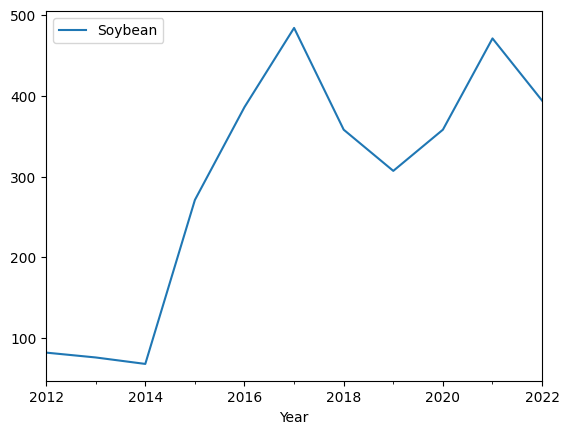

```python
crop_name = "Soybean"
fig1 = filtered_df.plot.line(x= "Year", y= crop_name)
fig1
```

```python
import plotly.express as px
import nbformat
px
```

```
<module 'plotly.express' from 'c:\\Users\\kennn\\AppData\\Local\\Programs\\Python\\Python311\\Lib\\site-packages\\plotly\\express\\__init__.py'>
```

Creating a list of relevant headers allows us to see all of the options on one graph

```python
headers = df.columns.values.tolist()
crop_options = headers[3:]
crop_options
#type(crop_options[0])
```

```
['Peanut', 'Rapeseed', 'Soybean', 'Local Soybean', 'Sunflowerseed']
```

```python
fig2 = px.line(filtered_df, x="Year", y= crop_options,
    title=f"Oilseed {attribute_name} from 2012-2022 in {country_name}")
fig2
```

[output not shown]

```python
country_names = df["Country"].drop_duplicates().sort_values().tolist()
# country_names = country_names.sort()
country_names
```

```
['Algeria',
 'Argentina',
 'Australia',
 'Bangladesh',
 'Barbados',
 'Belarus',
 'Benin',
 'Bolivia',
 'Bosnia and Herzegovina',
 'Brazil',
 'Burkina Faso',
 'Burma',
 'Cameroon',
 'Canada',
 'Central African Republic',
 'Chad',
 'Chile',
 'China',
 'Colombia',
 'Congo (Kinshasa)',
 'Costa Rica',
 "Cote d'Ivoire",
 'Cuba',
 'Ecuador',
 'Egypt',
 'Ethiopia',
 'European Union',
 'Gambia, The',
 'Ghana',
 'Guatemala',
 'Guinea',
 'Hong Kong',
 'India',
 'Indonesia',
 'Iran',
 'Israel',
 'Japan',
 'Kazakhstan',
 'Korea, North',
 'Korea, South',
```

[output cut: 30 more lines]

```
 'Togo',
 'Trinidad and Tobago',
 'Tunisia',
 'Turkey',
 'Uganda',
 'Ukraine',
 'United Arab Emirates',
 'United Kingdom',
 'United States',
 'Uruguay',
 'Uzbekistan',
 'Venezuela',
 'Vietnam',
 'Zambia',
 'Zimbabwe']
```